# MetaRE

Author

Sarah Urbut

Published

March 7, 2024

## Meta Analysis

Now we want to make a meta analysis

```r
library(dplyr)
library(ggplot2)
library(ggsci)
library(tidyverse)
library(data.table)
setwd("~/Dropbox (Personal)//PRS_ethnicity/")
UKB=readRDS("results_UKB.rds")
UKB_mid=readRDS("results_UKB_MID.rds")
UKB=rbind(UKB,UKB_mid)
UKB$study="ukb"
MGB=readRDS("results_mgb.rds")
MGB_mid=readRDS("results_mgb_mid.rds")
MGB=rbind(MGB,MGB_mid)
MGB$study="mgb"
AOU=readRDS("results_aou.rds")
AOU$study="aou"

AOU2=readRDS("results_aou_mid.rds")
AOU2$Population="mid"
AOU2$study="aou"



SAUDI=readRDS("results_saudi_combined.rds")
SAUDI$study="saudi"
SAUDI$Population="mid"

mideast=bind_rows(AOU2,SAUDI)

## gh

GH=fread("results_SAS.txt")[,-1]
GH$study="gh"

###BBJ
BBJ_ldl=fread("BBJLDLPRSandCAD.ldlprs.tsv")
BBJ_covs=fread("BBJLDLPRSandCAD.summary.tsv")
BBJ_ss=fread("BBJLDLPRSandCAD.sumstats.tsv")

### match org
BBJ=BBJ_ss
BBJ$Population="EAS"
BBJ=BBJ[,-c(1:3)]
BBJ$PRS_Mean=NA
BBJ$PRS_SD=NA
BBJ$Percent_male=(1-BBJ_covs$Female)
BBJ$LDL_Coef_CI_Lower=BBJ_ldl$beta-1.96*BBJ_ldl$se
BBJ$LDL_Coef_CI_Upper=BBJ_ldl$beta+1.96*BBJ_ldl$se
BBJ$Population_Scale_Factor=BBJ_ldl$prs_scale_factor
BBJ$LDL_Scaled_Coef_CI_Lower=NA
BBJ$LDL_Scaled_Coef_CI_Upper=NA
BBJ$HR=NA
BBJ$HR_CI_Lower=NA
BBJ$HR_CI_Upper=NA
BBJ$OR=BBJ_ss$OR
BBJ$OR_LCI=BBJ_ss$L95
BBJ$OR_UCI=BBJ_ss$U95
BBJ$study="bbj"

BBJ=BBJ


df_r=bind_rows(mideast,BBJ,UKB,MGB,AOU,GH)

df_r$log_or <- log(df_r$OR)
df_r$log_or_lower <- log(df_r$OR_LCI)
df_r$log_or_upper <- log(df_r$OR_UCI)
df_r$se_log_or <- (df_r$log_or_upper - df_r$log_or_lower) / (2 * 1.96)  # 1.96 is the Z-value for 95% CI

df_r$Population[df_r$Population=="afr"]="AFR"
df_r$Population[df_r$Population=="amr"]="AMR"
df_r$Population[df_r$Population=="eas"]="EAS"
df_r$Population[df_r$Population=="eur"]="EUR"
df_r$Population[df_r$Population=="sas"]="SAS"
df_r$Population[df_r$Population=="mid"]="MID"
df_r$Population=factor(df_r$Population)
df_r$study=factor(df_r$study)

df_r=df_r%>%arrange(Population,study)
meta_data=df_r[,c("Population","study","OR","OR_LCI","OR_UCI","log_or","se_log_or","HR", "HR_CI_Lower","HR_CI_Upper")]
rownames(meta_data)=interaction(meta_data$study,meta_data$Population)

meta_data[,-c(1,2)]=round(meta_data[,-c(1,2)],2)
write.csv(meta_data[,-c(6,7)],quote = F,row.names = F,"meta_table.csv")
```

To calculate $\tau^2$ when we are working with summary stats:

$\tau^2$=$\frac{max(0,\sum(wt)⋅(log_or−pooled_log_or^2)−(k−1))}{\sum(wt)}$

```r
library(metafor)
library(dplyr)
meta_data$wt = 1 / (meta_data$se_log_or^2)
results <- meta_data %>%
  group_by(Population) %>%
  summarize(
    pooled_log_or = sum(wt * log_or) / sum(wt),  # Weighted sum of log odds ratios
    pooled_log_or_se = sqrt(1 / sum(wt)),        # Standard error of the pooled log OR
    #tau2 = max(0, sum(wt * (log_or - pooled_log_or)^2) - (sum(wt) - sum(wt^2) / sum(wt))),
    tau2 = max(0, (sum(wt * (log_or - pooled_log_or)^2) - (length(log_or) - 1)) / sum(wt)),
    #I2 = ifelse(tau2 > 0, (tau2 - pooled_log_or_se^2) / (tau2 + pooled_log_or_se^2) * 100, 0)
    I2 = max(0, (tau2 / (tau2 + pooled_log_or_se^2)) * 100)
  ) %>%
  mutate(
    pooled_OR = exp(pooled_log_or),
    pooled_OR_LCI = exp(pooled_log_or - 1.96 * pooled_log_or_se),
    pooled_OR_UCI = exp(pooled_log_or + 1.96 * pooled_log_or_se),
    I2_label = paste0("I² = ", round(I2, 2), "%")  # Create a label for I2
  ) %>%
  ungroup()

# Print the heterogeneity statistics
print(results[, c("Population", "I2")])
```

```
# A tibble: 6 × 2
  Population    I2
  <fct>      <dbl>
1 AFR         66.7
2 AMR          0
3 EAS          0
4 EUR         98.5
5 MID         41.9
6 SAS         91.0
```

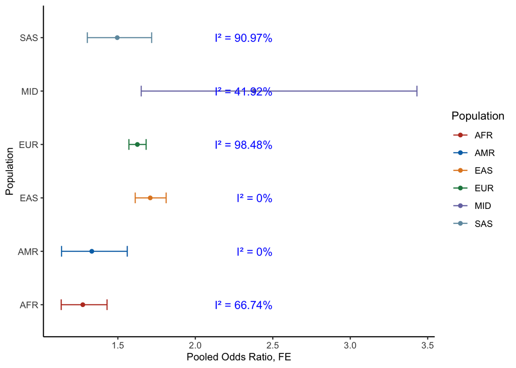

```r
# Create a prettier forest plot using ggplot2
ggplot(results, aes(x = pooled_OR, y = Population,color=Population)) +
  geom_point() +
  geom_errorbarh(aes(xmin =  pooled_OR_LCI, xmax = pooled_OR_UCI), height = 0.2) +
  labs(x = "Pooled Odds Ratio, FE", y = "Population") +
  scale_color_nejm()+
    geom_text(aes(label = I2_label, x = 2.5), hjust = 1, color = "blue") +  # Adjust 'x' for label position
  theme_classic() +
  theme(axis.text.y = element_text(size = 9), axis.title = element_text(size = 10))
```

# REML vs FE

Let’s also try with metafor. The default here is a random effect model in which the weights are a combination of tau and inverse variance weighting.

```r
library(metafor)
library(dplyr)


df_r$log_or <- log(df_r$OR)
df_r$log_or_lower <- log(df_r$OR_LCI)
df_r$log_or_upper <- log(df_r$OR_UCI)
df_r$se_log_or <- (df_r$log_or_upper - df_r$log_or_lower) / (2 * 1.96)  # 1.96 is the Z-value for 95% CI

results_by_population <- meta_data %>%
  group_by(Population) %>%
  do({
    mod <- rma(yi = log_or, sei = se_log_or, data = ., method = "REML")
    data.frame(
      Population = unique(.$Population),
      Pooled_OR = exp(mod$b),
      Lower_CI = exp(mod$ci.lb),
      Upper_CI = exp(mod$ci.ub),
      Tau2 = mod$tau2,
      I2 = mod$I2
    )
  }) %>%
  ungroup()

knitr::kable(results_by_population, digits = 3, caption = "Meta-Analysis Results by Population")
```

Meta-Analysis Results by Population

| Population | Pooled_OR | Lower_CI | Upper_CI | Tau2 | I2 |
| --- | --- | --- | --- | --- | --- |
| AFR | 1.238 | 1.016 | 1.509 | 0.016 | 50.005 |
| AMR | 1.332 | 1.136 | 1.561 | 0.000 | 0.000 |
| EAS | 1.638 | 1.341 | 2.002 | 0.011 | 9.292 |
| EUR | 1.433 | 1.128 | 1.821 | 0.043 | 96.570 |
| MID | 2.857 | 1.537 | 5.312 | 0.137 | 31.869 |
| SAS | 2.186 | 0.915 | 5.221 | 0.619 | 93.627 |

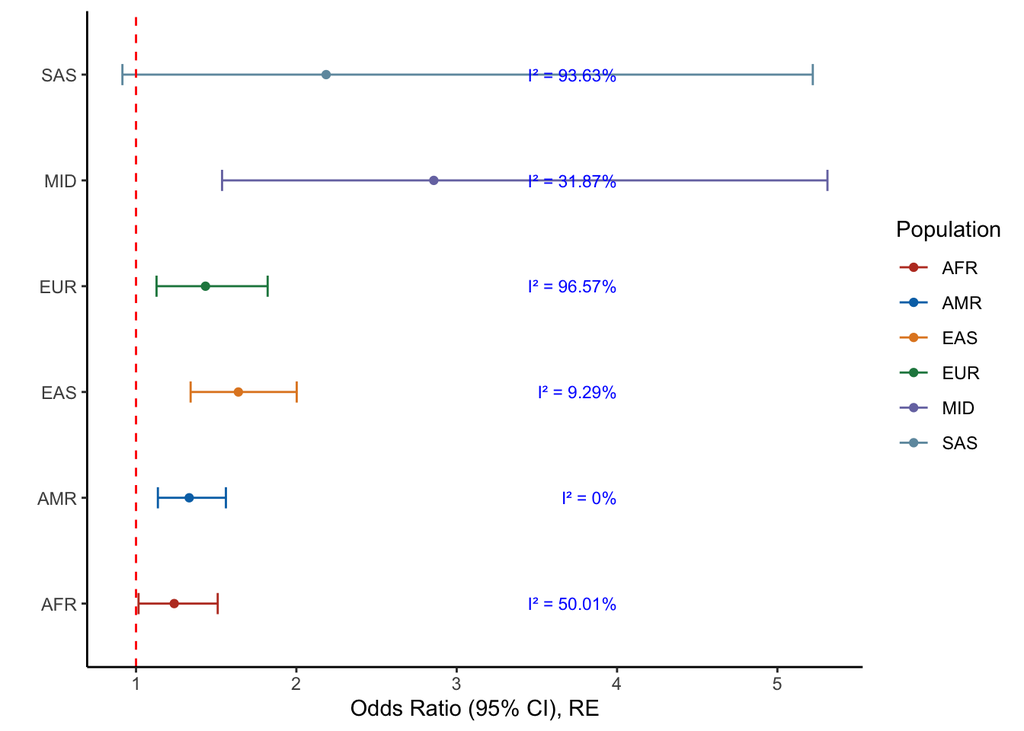

```r
  # Adding annotations for I2 and tau2
results_by_population %>%
  mutate(I2_label = paste0("I² = ", round(I2, 2), "%")) %>%
  ggplot(aes(y = Population, x = Pooled_OR, xmin = Lower_CI, xmax = Upper_CI,color=Population)) +
  geom_point() +
  scale_color_nejm()+
  geom_errorbarh(height = 0.2) +
  geom_vline(xintercept = 1, linetype = "dashed", color = "red") +
  geom_text(aes(label = I2_label,x=4), hjust = 1, color = "blue", size = 3) +

  xlab("Odds Ratio (95% CI), RE") +
  ylab("") +
  theme_classic()
```

We can also use metaFor for FE analysis: Here the estimated SE will inherently be smaller because we assume intra sutdy heterogeneity negligible.

```r
library(metafor)
library(dplyr)

results_by_population <- meta_data %>%
  group_by(Population) %>%
  do({
    mod <- rma(yi = log_or, sei = se_log_or, data = ., method = "FE")
    data.frame(
      Population = unique(.$Population),
      Pooled_OR = exp(mod$b),
      Lower_CI = exp(mod$ci.lb),
      Upper_CI = exp(mod$ci.ub),
      Tau2 = mod$tau2,
      I2 = mod$I2
    )
  }) %>%
  ungroup()

knitr::kable(results_by_population, digits = 3, caption = "Meta-Analysis Results by Population")
```

Meta-Analysis Results by Population

| Population | Pooled_OR | Lower_CI | Upper_CI | Tau2 | I2 |
| --- | --- | --- | --- | --- | --- |
| AFR | 1.274 | 1.134 | 1.430 | 0 | 50.083 |
| AMR | 1.332 | 1.136 | 1.561 | 0 | 0.000 |
| EAS | 1.709 | 1.612 | 1.812 | 0 | 0.000 |
| EUR | 1.626 | 1.571 | 1.682 | 0 | 97.013 |
| MID | 2.380 | 1.651 | 3.430 | 0 | 19.395 |
| SAS | 1.496 | 1.303 | 1.718 | 0 | 77.062 |

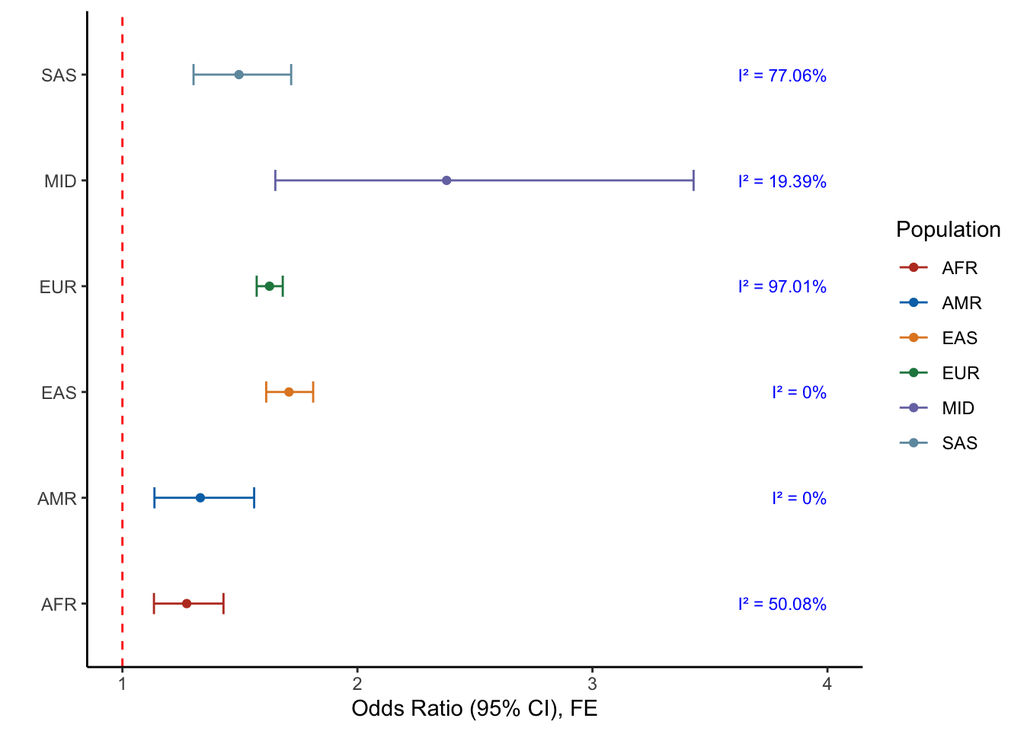

```r
  # Adding annotations for I2 and tau2
results_by_population %>%
  mutate(I2_label = paste0("I² = ", round(I2, 2), "%")) %>%
  ggplot(aes(y = Population, x = Pooled_OR, xmin = Lower_CI, xmax = Upper_CI,color=Population)) +
  geom_point() +
  scale_color_nejm()+
  geom_errorbarh(height = 0.2) +
  geom_vline(xintercept = 1, linetype = "dashed", color = "red") +
  geom_text(aes(label = I2_label,x=4), hjust = 1, color = "blue", size = 3) +

  xlab("Odds Ratio (95% CI), FE") +
  ylab("") +
  theme_classic()
```

### **And now pool all**

```r
library(dplyr)

# Assuming your results are stored in a dataframe named 'results'
global_effect <- results %>%
  summarise(
    global_log_or = sum(pooled_log_or / (pooled_log_or_se^2)) / sum(1 / (pooled_log_or_se^2)),
    se_global_log_or = sqrt(1 / sum(1 / (pooled_log_or_se^2)))
  ) %>%
  mutate(
    global_or = exp(global_log_or),
    global_or_lci = exp(global_log_or - 1.96 * se_global_log_or),
    global_or_uci = exp(global_log_or + 1.96 * se_global_log_or)
  )

print(global_effect)
```

```
# A tibble: 1 × 5
  global_log_or se_global_log_or global_or global_or_lci global_or_uci
          <dbl>            <dbl>     <dbl>         <dbl>         <dbl>
1         0.476           0.0140      1.61          1.57          1.65
```

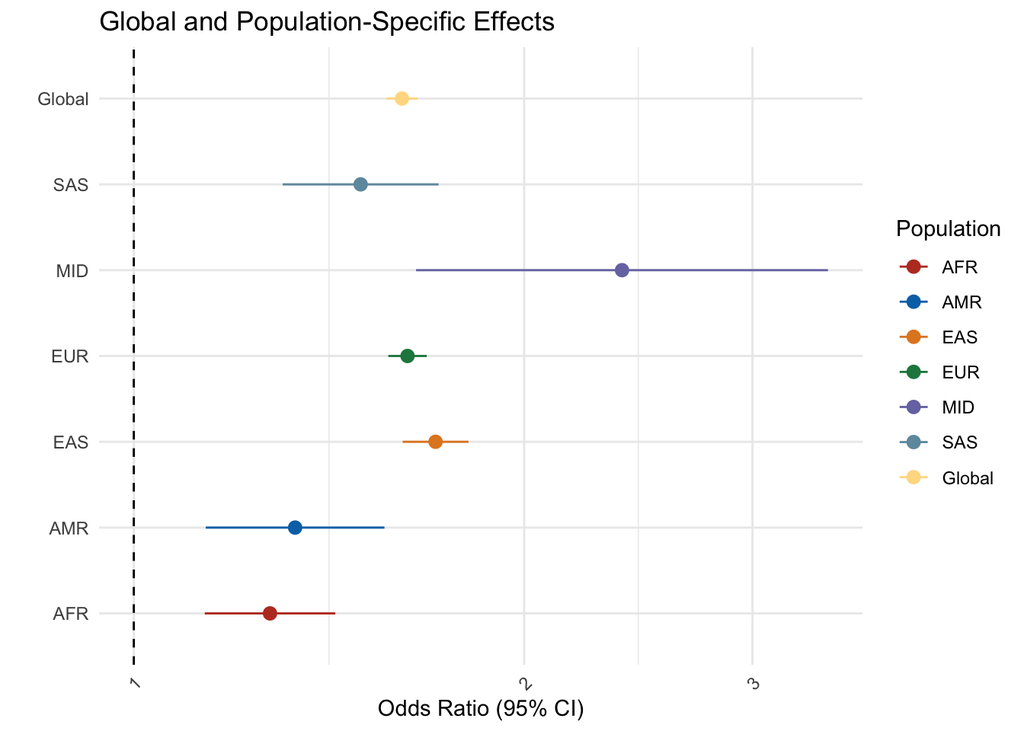

```r
library(ggplot2)

# Prepare data for plotting
plot_data <- results %>%
  dplyr::select(Population, pooled_OR, pooled_OR_LCI, pooled_OR_UCI) %>%
  mutate(Type = "Population-Specific")

global_plot_data <- data.frame(
  Population = "Global",
  pooled_OR = global_effect$global_or,
  pooled_OR_LCI = global_effect$global_or_lci,
  pooled_OR_UCI = global_effect$global_or_uci,
  Type = "Global"
)

plot_data <- rbind(plot_data, global_plot_data)

# Create the plot
ggplot(plot_data, aes(y = Population, x = pooled_OR, xmin = pooled_OR_LCI, xmax = pooled_OR_UCI, color = Population)) +scale_color_nejm()+
  geom_pointrange(position = position_dodge(width = 0.25), size = 0.5) +
  geom_vline(xintercept = 1, linetype = "dashed", color = "black") +
  scale_x_log10() + # Log scale for better visualization
  theme_minimal() +
  labs(x = "Odds Ratio (95% CI)", y = "", title = "Global and Population-Specific Effects") +
  theme(axis.text.x = element_text(angle = 45, hjust = 1), legend.position = "right")
```

```r
saveRDS(plot_data,"fixedeffect_plotdata.rds")
#
```

Can we estiamte heterogeneity?

```r
data=results
# Calculate weights as the inverse of the variance
data$weight <- 1 / (data$pooled_log_or_se^2)

# Calculate the weighted mean of the effect sizes
weighted_mean_effect <- sum(data$weight * data$pooled_log_or) / sum(data$weight)

# Calculate the Q statistic
data$squared_differences <- data$weight * (data$pooled_log_or - weighted_mean_effect)^2
Q <- sum(data$squared_differences)

# Degrees of freedom for the Q statistic is k - 1
df <- nrow(data) - 1

# Calculate the p-value for the Q statistic under a chi-square distribution
p_value <- pchisq(Q, df, lower.tail = FALSE)

cat("Weighted Mean Effect Size:", weighted_mean_effect, "\n")
```

```
Weighted Mean Effect Size: 0.4762266
```

```r
cat("Q statistic:", Q, "\n")
```

```
Q statistic: 30.98439
```

```r
cat("Degrees of freedom:", df, "\n")
```

```
Degrees of freedom: 5
```

```r
cat("P-value for Q statistic:", p_value, "\n")
```

```
P-value for Q statistic: 9.433975e-06
```

```r
### omit EAS
data=results[results$Population%in%c("AMR","AFR"),]
data$weight <- 1 / (data$pooled_log_or_se^2)
# Calculate the weighted mean of the effect sizes
weighted_mean_effect <- sum(data$weight * data$pooled_log_or) / sum(data$weight)

data$squared_differences <- data$weight * (data$pooled_log_or - weighted_mean_effect)^2
Q <- sum(data$squared_differences)

# Degrees of freedom for the Q statistic is k - 1
df <- nrow(data) - 1

# Calculate the p-value for the Q statistic under a chi-square distribution
p_value <- pchisq(Q, df, lower.tail = FALSE)

cat("Weighted Mean Effect Size:", weighted_mean_effect, "\n")
```

```
Weighted Mean Effect Size: 0.2573818
```

```r
cat("Q statistic:", Q, "\n")
```

```
Q statistic: 0.1976401
```

```r
cat("Degrees of freedom:", df, "\n")
```

```
Degrees of freedom: 1
```

```r
cat("P-value for Q statistic:", p_value, "\n")
```

```
P-value for Q statistic: 0.6566325
```

```r
#Bayes analysis:

#First conjugate normal approimation using weighted global mean as prior:
library(brms)
global_log_or_value=global_effect$global_log_or

se_global_log_or_value=global_effect$se_global_log_or

prior_mean=global_log_or_value
prior_variance=se_global_log_or_value^2

# Calculate variance and weights
results <- results %>%
  mutate(
    Variance = pooled_log_or_se^2,
    Weight = 1 / Variance
  )


# Perform Bayesian updating for each population
results <- results %>%
  mutate(
    Posterior_Variance = 1 / (1 / prior_variance + 1 / Variance),
    Posterior_Mean = Posterior_Variance * (prior_mean / prior_variance + pooled_log_or / Variance)
  )


print(results[,c("Population","pooled_log_or","pooled_log_or_se","Posterior_Mean","Posterior_Variance")])
```

```r
# And now with MCMC sampling

#To get an idea of heterogeneity

meta_model <- brm(
    bf(pooled_log_or | se(pooled_log_or_se) ~ 1 + (1 | Population)),
    data = results,
    family = gaussian(),
    prior = c(set_prior(sprintf("normal(%f, %f)", global_log_or_value, se_global_log_or_value), class = "Intercept"),
        prior(cauchy(0, 1), class = "sd")
    )
)


bayes_model=list()
for(pop in unique(results$Population)) {

  pop_data <- filter(results, Population == pop)

  bayes_model[[pop]] <- brm(
    bf(pooled_log_or ~ 1),
    data = pop_data,
    family = gaussian(),

      prior = c(set_prior(sprintf("normal(%f, %f)", global_log_or_value, se_global_log_or_value), class = "Intercept")),

    chains = 4, iter = 2000, warmup = 1000,silent = 2,
  )

  # Print or plot the results for each population as needed
}






meta_model <- brm(
  bf(pooled_log_or | se(pooled_log_or_se) ~ 1 + (1 | Population)),
  data = results,
  family = gaussian(),
  prior = c(
    prior(normal(0, 1), class = "Intercept"),
    prior(cauchy(0, 1), class = "sd")  # Prior for between-population variability
  )
)


library(dplyr)
library(tidyr)

posterior_summary <- lapply(seq(1:length(unique(results$Population))), function(x) {
  cbind(as.data.frame(summary(bayes_model[[x]])$fixed),
        Population = unique(results$Population)[x])
}) %>%
  bind_rows() %>%
  select(Population, Estimate = Estimate, CI.Lower = `l-95% CI`, CI.Upper = `u-95% CI`) %>%
  mutate(Type = "Posterior")

# Ensure Population is a factor for consistent ordering across plots
posterior_summary$Population <- factor(posterior_summary$Population, levels = unique(results$Population))



ps_df=posterior_summary[,c("Population","Estimate","CI.Lower","CI.Upper","Type")]
re_df=results[,c("Population","pooled_log_or","pooled_log_or_se")]
re_df$lower_ci_lo_or=re_df$pooled_log_or-1.96*re_df$pooled_log_or_se
re_df$upper_ci_lo_or=re_df$pooled_log_or+1.96*re_df$pooled_log_or_se

re_df=re_df[,c("Population","pooled_log_or","lower_ci_lo_or","upper_ci_lo_or")]
re_df$Type="Original"

colnames(ps_df)=colnames(re_df)

r=rbind(re_df,ps_df)

ggplot(r, aes(y = Population, x = exp(pooled_log_or), color = Population,shape=Type)) +
  geom_point(position = position_dodge(width = 0.25)) +
  geom_errorbar(aes(xmin = exp(lower_ci_lo_or), xmax = exp(upper_ci_lo_or)),
                width = 0.2, position = position_dodge(width = 0.25)) +
  theme_classic() +
  labs(x = "Bayesian Posterior on Pooled OR (95% CI)", y = "Population",shape="Estimate Type")+
  theme(axis.text.x = element_text(angle = 45, hjust = 1))


### draw from population
posterior_distributions <- lapply(names(bayes_model), function(pop) {
    as_draws_df(bayes_model[[pop]], variable = "b_Intercept") %>%
        mutate(Population = pop)
}) %>% bind_rows()


ggplot(posterior_distributions, aes(x = exp(b_Intercept), fill = Population)) +
    geom_density(alpha = 0.7) +
    facet_wrap(~Population, scales = "free") +
    labs(x = "Posterior distribution of Intercept (OR)", y = "Density") +
    theme_classic()+scale_fill_nejm()
```

### **Fixed-Effect Model (FE)**

#### Assumptions:

- **Homogeneity**: Assumes that all studies are estimating the same underlying effect size. Any observed variability across study estimates is due to within-study sampling error.
- **Weighting**: Studies are weighted by the inverse of their variance. Larger studies (lower variance) have more influence on the pooled estimate.

#### Tau-squared (τ²) and I-squared (I²):

- **τ² (Tau-squared)**: Not applicable or assumed to be 0 because between-study variability is not modeled in a fixed-effect framework.
- **I² (I-squared)**: Although not directly calculated in a traditional FE model, it can be interpreted in the context of how much variability is observed versus what would be expected under the assumption of homogeneity.

### **Random-Effects Model (REML)**

#### Assumptions:

- **Heterogeneity**: Acknowledges that the true effect sizes may vary across studies due to differences in study populations, interventions, or outcomes.
- **Weighting**: Studies are weighted by the inverse of the sum of their variance and an estimate of between-study variance (τ²). This accounts for both within-study variance and between-study variability.

#### Tau-squared (τ²) and I-squared (I²):

- **τ² (Tau-squared)**: Estimated from the data, reflecting the variance of the true effect sizes across studies.
- **I² (I-squared)**: Quantifies the proportion of total variation in study estimates due to heterogeneity rather than chance. Calculated using τ² and the within-study variances.

### **Why Results Differ:**

- **Incorporation of Between-Study Variability**: The key difference comes from how each model treats between-study variability. The REML model directly estimates and incorporates τ², leading to different weighting of studies compared to the FE model and potentially wider confidence intervals.
- **Estimation of Heterogeneity**: I² values can differ because they’re calculated based on τ² in the REML model. In the FE model, any observed variability beyond sampling error is not explicitly modeled, so calculating I² in this context reflects how poorly the homogeneity assumption holds.
- **Pooled Effect Estimate**: Differences in weighting schemes can lead to different pooled effect estimates. The REML model can give more weight to smaller studies when there’s significant between-study variability, potentially leading to a different overall effect size than the FE model.

## Overall

  We’d also like to plot a meta analysis by study:

```r
library(metafor)
library(meta)
study_data=df_r

study_data$identifier <- paste(study_data$study, study_data$Population, sep = "_")

# Perform the meta-analysis
meta_analysis <- metagen(
  TE = study_data$log_or,
  seTE = study_data$se_log_or,
  studlab = study_data$identifier,
  data = study_data,
  sm = "OR"  # Specify that the summary measure is Odds Ratio
)

# Summary of the meta-analysis
summary(meta_analysis)
```

```
               OR            95%-CI %W(common) %W(random)
aou_AFR    1.3300 [1.1602;  1.5246]        4.0        9.1
mgb_AFR    0.9900 [0.7515;  1.3043]        1.0        6.2
ukb_AFR    1.4000 [0.9748;  2.0106]        0.6        4.8
aou_AMR    1.3400 [1.0924;  1.6437]        1.8        7.7
mgb_AMR    1.3000 [0.9804;  1.7239]        0.9        6.1
ukb_AMR    2.4300 [0.5267; 11.2101]        0.0        0.5
aou_EAS    1.2200 [0.5758;  2.5851]        0.1        1.7
bbj_EAS    1.7168 [1.6224;  1.8166]       23.1       10.3
mgb_EAS    1.8700 [0.5922;  5.9046]        0.1        0.8
ukb_EAS    0.9000 [0.3367;  2.4060]        0.1        1.1
aou_EUR    1.4500 [1.3231;  1.5890]        8.8        9.9
mgb_EUR    1.1500 [1.0397;  1.2720]        7.3        9.7
ukb_EUR    1.7500 [1.6826;  1.8201]       47.8       10.5
aou_MID    2.2300 [0.3198; 15.5502]        0.0        0.3
mgb_MID    6.7100 [1.2211; 36.8727]        0.0        0.4
saudi_MID  2.0200 [1.3314;  3.0648]        0.4        4.1
ukb_MID    4.6600 [1.6746; 12.9677]        0.1        1.0
aou_SAS    1.1700 [0.4187;  3.2694]        0.1        1.0
gh_SAS     1.3800 [1.1829;  1.6100]        3.1        8.7
mgb_SAS   16.9200 [3.4936; 81.9453]        0.0        0.4
ukb_SAS    1.9300 [1.4218;  2.6198]        0.8        5.7

Number of studies: k = 21

                         OR           95%-CI     z  p-value
Common effect model  1.6123 [1.5691; 1.6567] 34.47 < 0.0001
Random effects model 1.4763 [1.3262; 1.6433]  7.12 < 0.0001

Quantifying heterogeneity:
 tau^2 = 0.0281 [0.0164; 0.5387]; tau = 0.1676 [0.1282; 0.7339]
 I^2 = 83.3% [75.6%; 88.6%]; H = 2.45 [2.02; 2.96]

Test of heterogeneity:
      Q d.f.  p-value
 119.85   20 < 0.0001

Details on meta-analytical method:
- Inverse variance method
- Restricted maximum-likelihood estimator for tau^2
- Q-Profile method for confidence interval of tau^2 and tau
```

[figure not shown]

```r
# Forest plot to visualize the results
forest(meta_analysis)
```

We can also use a fixed and random analysis, but this is completely agnostic to shared populations. The random effects assumes each study:opulation effectively arises from it’s own distritbuion

```r
library(metafor)
fixed_effect_model <- rma(yi = log_or, sei = se_log_or, method = "FE", data = df_r)
summary(fixed_effect_model)
```

```
Fixed-Effects Model (k = 21)

  logLik  deviance       AIC       BIC      AICc
-45.1792  119.8498   92.3584   93.4029   92.5689

I^2 (total heterogeneity / total variability):   83.31%
H^2 (total variability / sampling variability):  5.99

Test for Heterogeneity:
Q(df = 20) = 119.8498, p-val < .0001

Model Results:

estimate      se     zval    pval   ci.lb   ci.ub
  0.4777  0.0139  34.4734  <.0001  0.4505  0.5048  ***

---
Signif. codes:  0 '***' 0.001 '**' 0.01 '*' 0.05 '.' 0.1 ' ' 1
```

```r
# Random-effects model
random_effects_model <- rma(yi = log_or, sei = se_log_or, method = "REML", data = df_r)
summary(random_effects_model)
```

```
Random-Effects Model (k = 21; tau^2 estimator: REML)

  logLik  deviance       AIC       BIC      AICc
-11.2980   22.5960   26.5960   28.5875   27.3019

tau^2 (estimated amount of total heterogeneity): 0.0281 (SE = 0.0159)
tau (square root of estimated tau^2 value):      0.1676
I^2 (total heterogeneity / total variability):   83.70%
H^2 (total variability / sampling variability):  6.13

Test for Heterogeneity:
Q(df = 20) = 119.8498, p-val < .0001

Model Results:

estimate      se    zval    pval   ci.lb   ci.ub
  0.3895  0.0547  7.1238  <.0001  0.2823  0.4967  ***

---
Signif. codes:  0 '***' 0.001 '**' 0.01 '*' 0.05 '.' 0.1 ' ' 1
```

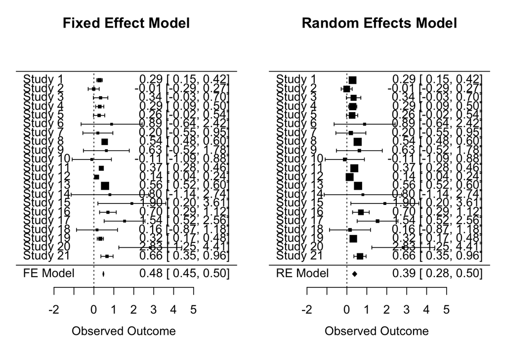

```r
# Forest plot to visualize the results
par(mfrow=c(1,2))  # Arrange plots side by side
forest(fixed_effect_model, main="Fixed Effect Model")
forest(random_effects_model, main="Random Effects Model")
```

```r
#Let's try with a nested Hierarchical structure:
library(metafor)

# Fitting the multi-level random effects model
multi_level_model <- rma.mv(yi = log_or, V = se_log_or^2, random = ~ 1 | study/Population, data = df_r, method = "REML")

# Display the summary of the model
summary(multi_level_model)

library(tidyverse)

random_effects <- ranef(multi_level_model)
# Convert the list to a data frame for plotting
# Note: Adjust the code below if the structure of your list differs

# For study level
df_study <- as.data.frame(random_effects$study) %>%
  rownames_to_column(var = "Study")

# For study/population level
df_population <- as.data.frame(random_effects$`study/Population`) %>%
  rownames_to_column(var = "StudyPopulation") %>%
  separate(StudyPopulation, into = c("Study", "Population"), sep = "/",remove = FALSE)

# Combine the data frames for a unified plot (optional)
df_combined <- bind_rows(
  df_study %>% mutate(Level = "Study"),
  df_population %>% mutate(Level = "Population")
)

ggplot(df_combined, aes(x = intrcpt, y = StudyPopulation, xmin = pi.lb, xmax = pi.ub, color = Level)) +
  geom_point() +
  geom_errorbar() +
  labs(x = "Random Effects Estimate (logOR)", y = "Study / Population", color = "Level") +
  theme_minimal() +
  theme(legend.position = "bottom")
```

Let’s run a Bayesian meta analysis:

```
library(brms)
bayes_model <- brm(
bf(log_or ~ 0 + Population + (1|study), sigma ~ 0 + Population),
data = meta_data,
family = gaussian(),
prior = c(
prior(normal(0, 1), class = "b"),
prior(exponential(1), class = "sd")
),
chains = 4, iter = 8000, warmup = 2000,
control = list(adapt_delta = 0.99)
)
```